# Alpha-diversity

Yanxian Li

2020-10-16 07:57:18

# Getting ready

Load packages

```r
library(here) # [CRAN] A replacement for 'file.path()', locating the files relative to the project root
library(tidyverse) # [CRAN] Easily install and load the 'Tidyverse'
library(cowplot)  # [CRAN] Streamlined plot theme and plot annotations for 'ggplot2'
library(RColorBrewer) # [CRAN] ColorBrewer Palettes
library(gridExtra) # [CRAN] Miscellaneous functions for "Grid" graphics
library(ggsignif) # [CRAN] Statistical significance labelling
library(phyloseq) # [Bioconductor] Handling and analysis of high-throughput microbiome census data
library(microbiome) # [Bioconductor] Microbiome analytics
library(picante) # [CRAN] Integrating phylogenies and ecology
library(lmerTest) # [CRAN] Fits and tests in linear mixed effects models
library(ggResidpanel) # [CRAN] Panels and interactive versions of diagnostic plots using 'ggplot2'
library(emmeans) # [CRAN] Post-hoc tests for fixed effects using least-squares means

# Set seed
set.seed(1910)
```

Import data

```r
load(here("data", "qiime2R", "phyloseq.RData"))

# Extract metadata from the phyloseq object
metadata <- data.frame(sample_data(phyloseq), check.names = FALSE)
```

# Compute alpha-diversity

Here, we compute the alpha-diversity via the `alpha()` and `pd()` function from the *microbiome* and *picante* package, respectively.

```r
# Compute Observed features, Peilou's Evenness and Shannon's index
adiv_npd <- alpha(phyloseq, index = c("observed", "evenness_pielou", "diversity_shannon")) %>%
  rownames_to_column("SampleID")

# Compute Faith's Phylogenetic Diversity
adiv_pd <- pd(samp = t(otu_table(phyloseq)), tree = phy_tree(phyloseq), include.root = F) %>%
  select(PD) %>%
  rownames_to_column("SampleID")

# Putting together
adiv <- inner_join(adiv_npd, adiv_pd, by = "SampleID") %>%
  inner_join(rownames_to_column(metadata, "SampleID"), by = "SampleID") %>%
  rename("observed ASVs" = observed, "Pielou's evenness" = evenness_pielou,
         "Shannon's index" = diversity_shannon, "Faith's PD" = PD) %>%
  gather("adiv", "value", "observed ASVs":"Faith's PD") %>%
  mutate(FishID = as.character(FishID), NetPen = as.character(NetPen),
         adiv = factor(adiv, levels = c("observed ASVs", "Pielou's evenness", "Shannon's index", "Faith's PD")))
```

# Plot alpha-diversity

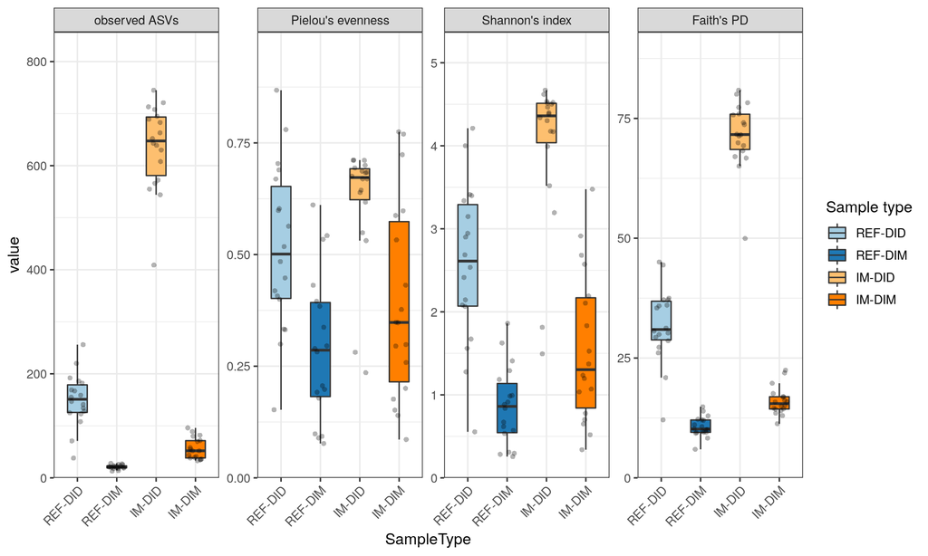

```r
p <- ggplot(adiv, aes(x = SampleType, y = value)) +
  geom_boxplot(aes(fill = SampleType), outlier.shape = NA, width = 0.5) +
  geom_jitter(shape = 16, position = position_jitter(0.2), alpha = 0.3) +
  facet_wrap(~adiv, nrow = 1, scales = "free_y") +
  scale_y_continuous(limits = c(0, NA), expand = expand_scale(mult = c(0, 0.15))) +
  scale_fill_manual(values = brewer.pal(n = 12, name = "Paired")[c(1,2,7,8)]) +
  labs(fill = "Sample type") +
  theme_bw(base_size = 12) +
  theme(axis.text.x = element_text(angle = 45, hjust = 1))
p
```

# Alpha-diversity group significance

## Fit linear mixed effects models

The alpha-diversity plot showed different dispersions among the sample type. Hence, we’ll log transform the response variables to stabilize the mean-variance relationship

```r
# Split the dataframe by alpha-diversity indices
adiv_spl <- split(adiv, f = adiv$adiv)

# Fit model
lme <- lapply(adiv_spl, function(x)
              lmer(log(value + 1) ~ Diet * SampleOrigin + (1|FishID) + (1|NetPen), data = x))
```

```
## boundary (singular) fit: see ?isSingular
```

One of the fitted models is singular. Let’s look at the fitted models and find out which one is singular.

```r
lme
```

```
## $`observed ASVs`
## Linear mixed model fit by REML ['lmerModLmerTest']
## Formula: log(value + 1) ~ Diet * SampleOrigin + (1 | FishID) + (1 | NetPen)
##    Data: x
## REML criterion at convergence: 40.5779
## Random effects:
##  Groups   Name        Std.Dev.
##  FishID   (Intercept) 0.12065
##  NetPen   (Intercept) 0.03725
##  Residual             0.27489
## Number of obs: 72, groups:  FishID, 36; NetPen, 6
## Fixed Effects:
##                (Intercept)                     DietREF          SampleOriginMucosa  DietREF:SampleOriginMucosa
##                     6.4466                     -1.4998                     -2.4641                      0.5916
##
## $`Pielou's evenness`
## Linear mixed model fit by REML ['lmerModLmerTest']
## Formula: log(value + 1) ~ Diet * SampleOrigin + (1 | FishID) + (1 | NetPen)
##    Data: x
## REML criterion at convergence: -77.8943
## Random effects:
##  Groups   Name        Std.Dev.
##  FishID   (Intercept) 0.06422
##  NetPen   (Intercept) 0.00000
##  Residual             0.11008
## Number of obs: 72, groups:  FishID, 36; NetPen, 6
## Fixed Effects:
##                (Intercept)                     DietREF          SampleOriginMucosa  DietREF:SampleOriginMucosa
##                   0.476113                   -0.067955                   -0.155459                   -0.005022
## convergence code 0; 1 optimizer warnings; 0 lme4 warnings
##
## $`Shannon's index`
## Linear mixed model fit by REML ['lmerModLmerTest']
## Formula: log(value + 1) ~ Diet * SampleOrigin + (1 | FishID) + (1 | NetPen)
##    Data: x
## REML criterion at convergence: 33.8044
## Random effects:
##  Groups   Name        Std.Dev.
##  FishID   (Intercept) 1.388e-01
##  NetPen   (Intercept) 5.896e-05
##  Residual             2.533e-01
## Number of obs: 72, groups:  FishID, 36; NetPen, 6
## Fixed Effects:
##                (Intercept)                     DietREF          SampleOriginMucosa  DietREF:SampleOriginMucosa
##                     1.5827                     -0.3481                     -0.6987                      0.0560
##
## $`Faith's PD`
## Linear mixed model fit by REML ['lmerModLmerTest']
## Formula: log(value + 1) ~ Diet * SampleOrigin + (1 | FishID) + (1 | NetPen)
##    Data: x
## REML criterion at convergence: -16.7949
## Random effects:
##  Groups   Name        Std.Dev.
##  FishID   (Intercept) 0.07789
##  NetPen   (Intercept) 0.02762
##  Residual             0.18049
## Number of obs: 72, groups:  FishID, 36; NetPen, 6
## Fixed Effects:
##                (Intercept)                     DietREF          SampleOriginMucosa  DietREF:SampleOriginMucosa
##                     4.2784                     -0.8176                     -1.4563                      0.4365
## convergence code 0; 1 optimizer warnings; 0 lme4 warnings
```

From the model outputs, we can see that the standard deviation of random effect `NetPen` for Pielou’s evenness is zero, which indicates boundary fit. We’ll update the model by removing the random effect `NetPen`.

```r
lme <- lapply(lme, function(x)
              if(is.null(x@optinfo$conv$lme4$messages)) {
                x
              } else {
                update(x, . ~ . -(1|NetPen))}
              )
```

The updated model is not singular after removing the random effect `NetPen`. We proceed to model diagnostics.

## Model diagnostics

Here we use the *ggResidpanel* package to produce a panel of plots for residual diagnostics.

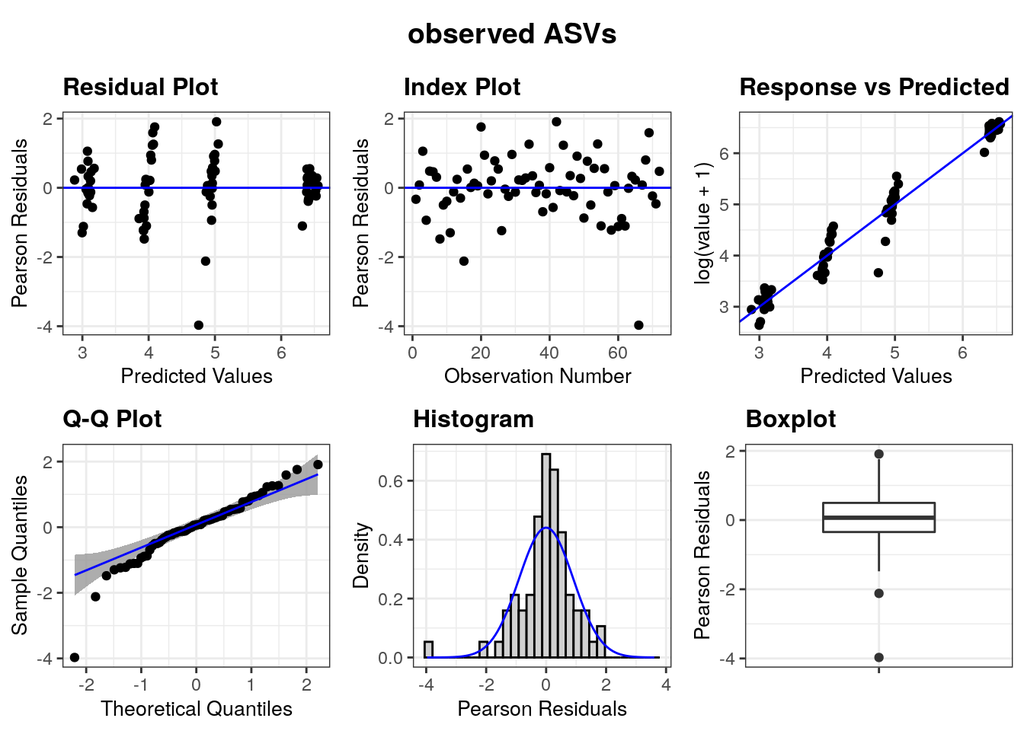

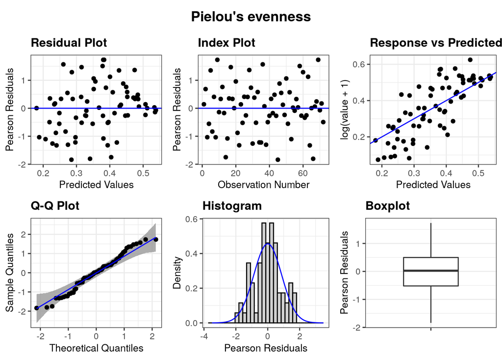

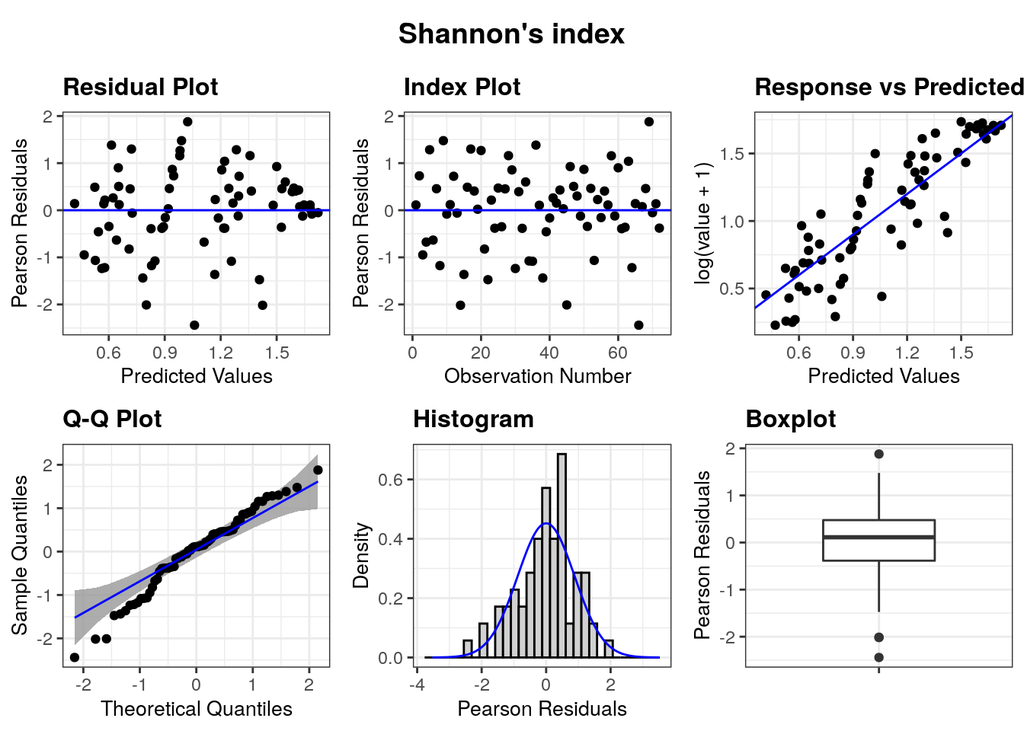

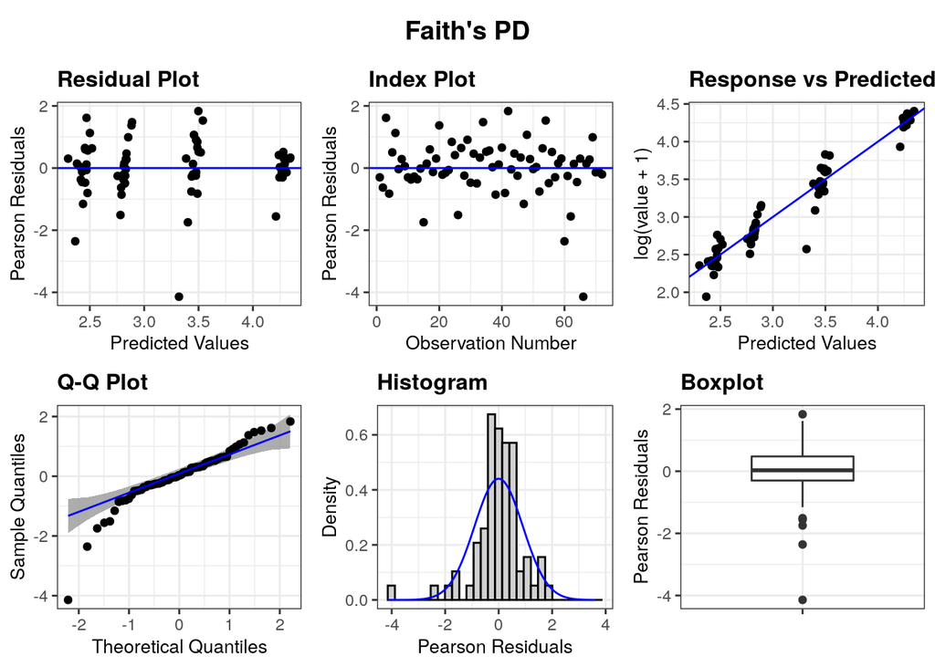

```r
lapply(
  seq_along(lme),
  function(x)
  {
    # Extract titles
    main <- ggdraw() + draw_label(names(lme)[x], fontface='bold')
    # Make residual diagnostic plots
    resid_panel <- resid_panel(lme[[x]], plots = "all", qqbands = TRUE)
    # Assemble plots
    plot_grid(main, resid_panel, ncol = 1, rel_heights = c(1, 10))
  }
)
```

Visual inspection of residual plots does not reveal obvious deviations from homoscedasticity or normality. Let’s proceed to the the significance testing of fixed effects.

## Inference

For the significance testing of fixed effects, the likelihood ratio test (LRT) is often used. However, it can produce anti-conservative *p* values in situations where the data is unbalanced or the number of parameters is large compared to the number of observations. A better alternative is to use F test with Satterthwaite/Kenward-Roger approximation available from the *lmerTest* package.

```r
fixef <- lapply(lme, function(x) anova(x, ddf = "Kenward-Roger"))
fixef
```

```
## $`observed ASVs`
## Type III Analysis of Variance Table with Kenward-Roger's method
##                   Sum Sq Mean Sq NumDF DenDF  F value    Pr(>F)
## Diet              16.252  16.252     1     4  215.085 0.0001258 ***
## SampleOrigin      84.625  84.625     1    34 1119.945 < 2.2e-16 ***
## Diet:SampleOrigin  1.575   1.575     1    34   20.842 6.243e-05 ***
## ---
## Signif. codes:  0 '***' 0.001 '**' 0.01 '*' 0.05 '.' 0.1 ' ' 1
##
## $`Pielou's evenness`
## Type III Analysis of Variance Table with Kenward-Roger's method
##                    Sum Sq Mean Sq NumDF DenDF F value    Pr(>F)
## Diet              0.05318 0.05318     1    34  4.3881   0.04371 *
## SampleOrigin      0.44918 0.44918     1    34 37.0655 6.619e-07 ***
## Diet:SampleOrigin 0.00011 0.00011     1    34  0.0094   0.92348
## ---
## Signif. codes:  0 '***' 0.001 '**' 0.01 '*' 0.05 '.' 0.1 ' ' 1
##
## $`Shannon's index`
## Type III Analysis of Variance Table with Kenward-Roger's method
##                   Sum Sq Mean Sq NumDF DenDF  F value    Pr(>F)
## Diet              1.1523  1.1523     1     4  17.9519    0.0133 *
## SampleOrigin      8.0978  8.0978     1    34 126.1616 5.486e-13 ***
## Diet:SampleOrigin 0.0141  0.0141     1    34   0.2198    0.6422
## ---
## Signif. codes:  0 '***' 0.001 '**' 0.01 '*' 0.05 '.' 0.1 ' ' 1
##
## $`Faith's PD`
## Type III Analysis of Variance Table with Kenward-Roger's method
##                    Sum Sq Mean Sq NumDF DenDF F value    Pr(>F)
## Diet               4.6015  4.6015     1    34 141.242 1.176e-13 ***
## SampleOrigin      27.5895 27.5895     1    34 846.860 < 2.2e-16 ***
## Diet:SampleOrigin  0.8573  0.8573     1    34  26.315 1.166e-05 ***
## ---
## Signif. codes:  0 '***' 0.001 '**' 0.01 '*' 0.05 '.' 0.1 ' ' 1
```

## Conditional contrasts

When interactions between main factors are significant, marginal means averaged over the levels of other covariates in the model can be misleading. A good practice is to specify conditional contrasts through the use of the `simple` argument to `contrast()`.

```r
# Filter alpha-diversity indices showing significant interactions between the main effects
interact <- lapply(fixef, function(x) ifelse(x["Diet:SampleOrigin", "Pr(>F)"] < 0.05, TRUE, FALSE))

# Conditional contrasts
cc <- mapply(function(x, y){
  # Compute estimated marginal means
  emm <- emmeans(x, ~ Diet * SampleOrigin)

  # Make conditional contrasts if the interaction is significant
  if (y == TRUE){
    contrast(emm, method = "consec", simple = "each", combine = TRUE, adjust = "mvt") %>%
    summary()
  }
},
  x = lme,
  y = interact
)

cc
```

```
## $`observed ASVs`
##  SampleOrigin Diet contrast         estimate     SE   df t.ratio p.value
##  Digesta      .    REF - IM           -1.500 0.1046 10.1 -14.341 <.0001
##  Mucosa       .    REF - IM           -0.908 0.1046 10.1  -8.684 <.0001
##  .            IM   Mucosa - Digesta   -2.464 0.0916 34.0 -26.892 <.0001
##  .            REF  Mucosa - Digesta   -1.872 0.0916 34.0 -20.436 <.0001
##
## Degrees-of-freedom method: kenward-roger
## Results are given on the log (not the response) scale.
## P value adjustment: mvt method for 4 tests
##
## $`Pielou's evenness`
## NULL
##
## $`Shannon's index`
## NULL
##
## $`Faith's PD`
##  SampleOrigin Diet contrast         estimate     SE   df t.ratio p.value
##  Digesta      .    REF - IM           -0.818 0.0660 66.1 -12.392 <.0001
##  Mucosa       .    REF - IM           -0.381 0.0660 66.1  -5.777 <.0001
##  .            IM   Mucosa - Digesta   -1.456 0.0602 34.0 -24.205 <.0001
##  .            REF  Mucosa - Digesta   -1.020 0.0602 34.0 -16.950 <.0001
##
## Degrees-of-freedom method: kenward-roger
## Results are given on the log (not the response) scale.
## P value adjustment: mvt method for 4 tests
```

# Display effects

## *P*-value annotation: main effects

Gather and merge *p* values of the main effects.

```r
p_fixef <- lapply(fixef, function(x) rownames_to_column(x, "term")) %>%
  bind_rows(.id = "adiv") %>%
  rename(pval = "Pr(>F)") %>%
  mutate(pval = formatC(pval, format = "f", digits = 3),
         # "==" gets handled as a "=" in R expressions
         pval = paste0("p == ", pval),
         pval = gsub("p == 0.000", "p < 0.001", pval),
         term = gsub("Diet:SampleOrigin", "Interaction", term),
         # tilde (~) gets handled as a "space" in R expressions
         term = gsub("SampleOrigin", "Sample~origin", term),
         label = paste0(term, ": ", pval),
         # use italic font for "p". Surround pattern by "\\b" for exact match
         label = gsub("\\bp\\b", "italic(p)", label))
```

## *P*-value annotation: conditional contrasts

Gather and merge *p* values of the conditional contrasts.

```r
# Gather p values
p_cc <- bind_rows(cc, .id = "adiv")

# Make a dataframe for conditional p value annotation
anno1 <- filter(p_cc, SampleOrigin != ".") %>%
  mutate(SampleOrigin = gsub("Digesta", "DID", SampleOrigin),
         SampleOrigin = gsub("Mucosa", "DIM", SampleOrigin)) %>%
  separate(contrast, sep = " - ", c("start", "end")) %>%
  mutate(start = paste0(start, "-", SampleOrigin),
         end = paste0(end, "-", SampleOrigin))

anno2 <- filter(p_cc, Diet != ".") %>%
  mutate(contrast = gsub("Digesta", "DID", contrast),
         contrast = gsub("Mucosa", "DIM", contrast)) %>%
  # the "end" comes before "start" because we need to use "REF-DID" as the starting point
  separate(contrast, sep = " - ", c("end", "start")) %>%
  mutate(start = paste0(Diet, "-", start),
         end = paste0(Diet, "-", end))

anno <- bind_rows(anno1, anno2) %>%
  select(adiv, start, end, p.value) %>%
  # the columns are arranged in a way that p value annotation starts from left to right
  arrange(match(adiv, c("observed ASVs", "Pielou's evenness", "Shannon's index", "Faith's PD")),
          match(start, c("REF-DID", "REF-DIM", "IM-DID")),
          match(end, c("REF-DIM", "IM-DID"))) %>%
  # the following 4 lines of code convert p values to the corresponding asterisks
  mutate(p.value = ifelse(p.value < 0.001, "***", p.value),
         p.value = ifelse(p.value >= 0.001 & p.value < 0.01, "**", p.value),
         p.value = ifelse(p.value >= 0.01 & p.value < 0.05, "*", p.value),
         p.value = ifelse(p.value >= 0.05, "NS", p.value),
         # position of p value label on the y axis
         y = c(720, 770, 830, 890, 80, 85, 92, 99),
         # ensure alpha-diversity indices are plotted in the desired order
         adiv = factor(adiv, levels = c("observed ASVs", "Pielou's evenness", "Shannon's index", "Faith's PD")))
```

## Annotate the plot

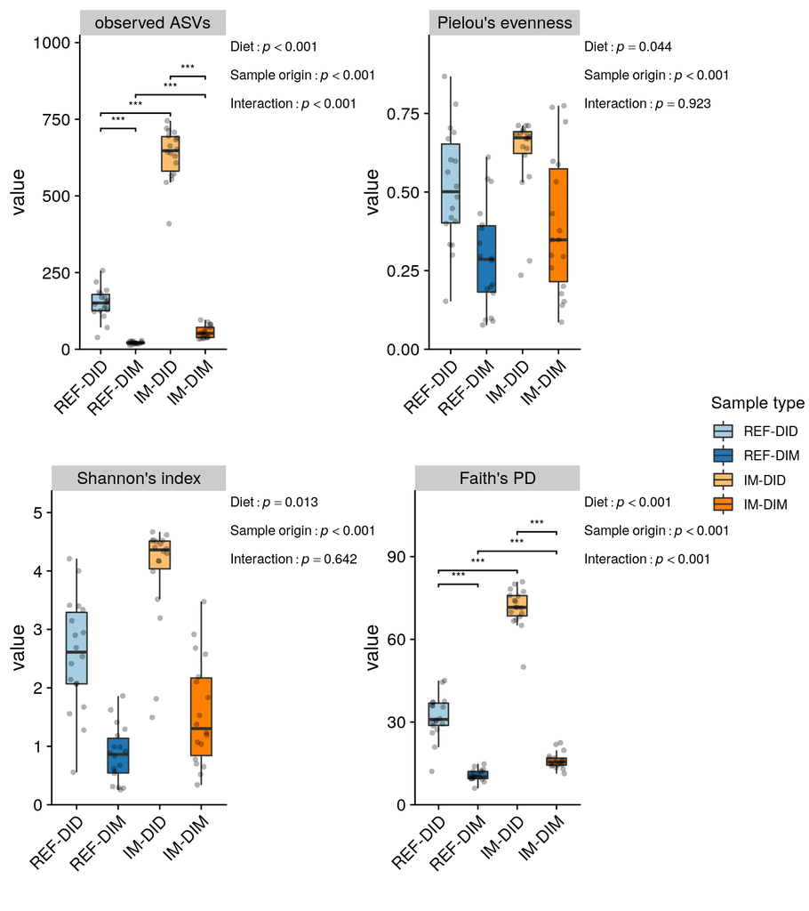

```r
# Make a list of alpha-diversity plots
p_list <- lapply(
  as.list(levels(adiv$adiv)),
  function(x)
  {
    # Make an inital plot
    p <- filter(adiv, adiv == x) %>%
      ggplot(aes(x = SampleType, y = value)) +
      geom_boxplot(aes(fill = SampleType), outlier.shape = NA, width = 0.5) +
      geom_jitter(shape = 16, position = position_jitter(0.2), alpha = 0.3) +
      facet_wrap(~adiv, nrow = 1, scales = "free_y") +
      scale_y_continuous(limits = c(0, NA), expand = expand_scale(mult = c(0, 0.15))) +
      labs(x = "") +
      theme_cowplot() +
      scale_fill_manual(values = brewer.pal(n = 12, name = "Paired")[c(1,2,7,8)]) +
      theme(axis.text.x = element_text(angle = 45, hjust = 1),legend.position = "none")

    # Add p values of conditional contrasts to the plot
    if (x %in% levels(anno$adiv)) {
      p <- p + geom_signif(data = filter(anno, adiv == x),
                           aes(xmin = start, xmax = end, annotations = p.value, y_position = y),
                           map_signif_level = TRUE,
                           tip_length = 0.01,
                           textsize = 3,
                           manual = T)
      }

    # Convert the table containing p values of main effects to a grid graphic
    tg <- filter(p_fixef, adiv == x) %>%
      select(label) %>%
      # the following 2 lines of code remove rownames and column names
      as.matrix() %>%
      unname() %>%
      # set "parse=TRUE" to parse the plotmath expression
      tableGrob(theme = ttheme_minimal(core = list(fg_params = list(hjust = 0, x = 0.1, parse = TRUE, cex = 0.8)),
                                       rowhead = list(fg_params = list(hjust = 0, x = 0))))

    # Assemble plots
    lab <- plot_grid(tg, NULL, labels = "", ncol = 1, rel_heights = c(1, 2))
    plot_grid(p, lab, labels = "", ncol = 2, rel_widths = c(2, 1))
  }
)

# Get figure legend
legend <- get_legend(p)

# Assemble plots
prow <- plot_grid(plotlist = p_list, ncol = 2, align = 'v', axis = "lr", labels = "")

# Add legend to the assembled plot
plot_grid(prow, legend, rel_widths = c(7, 1))
```

```r
# Export figure
ggsave(here("result", "figures", "Figure 3.tiff"), width = 8, height = 9,
       units = "in", dpi = 300, compression = "lzw")
```